# ggplot2 Basic in R

Lim wonki

2019. 06. 18.

##### **모든 내용의 출처는 [coder1252님의 블로그](https://m.blog.naver.com/coder1252/220931262683)입니다.**

##### **목차**

1. ggplot2 소개  
   1.1 ggplot2란?  
   1.2 ggplot2의 핵심 - layer 추가  
   1.3 레이어 추가를 통해 기본 그래프 그려보기
2. geom_bar  
   2.1 x축 값만 지정한 그래프  
   2.2 x축, y축 값을 지정한 그래프  
   2.2.1 기본 bar 그래프  
   2.2.2 데이터의 종류를 한 그래프 안에 나눠서 표시해주는 bar 그래프  
   2.2.3 데이터의 종류를 나눠 따로 표시해주는 bar 그래프  
   2.2.4 데이터의 종류를 비율로 표시해주는 bar 그래프  
   2.2.5 가로로 눕힌 bar 그래프  
   2.2.6 복수의 데이터를 나란히 표현해주는 가로 그래프  
   2.2.7 음수와 양수 막대 다르게 색상 입히기  
   2.2.8 막대 그래프를 이용한 파이-도넛 차트
3. geom_point / jitter
4. geom_line
5. geom_segment
6. geom_boxplot
7. geom_ribbon & area
8. geom_errorbar
9. geom_treemap
10. geom_bin2d

## **1. ggplot2 소개**

#### **1.1 ggplot2란?**

R 의 데이터 시각화 패키지로서 엑셀, 파워포인트와는 다르게 함수를 입력하여 그래프를 그릴 수 있습니다.

#### **1.2 ggplot2의 핵심 - layer 추가**

ggplot2의 장점에는 여러가지가 있습니다. 일관된 기초 문법을 가지고 있으며, 함수가 직관적이고,  
그래픽 시스템의 완성도가 높습니다. 그 중 주목할 만한 장점은 레이어 추가 방식입니다.  
ggplot2 함수는 기본적으로 레이어를 추가하는 방식으로 그래프를 그려나갑니다. 패션에서 레이어드 룩과 같이  
ggplot2 함수도 레이어를 추가해 가면서 그래프를 꾸미고 정보를 더해 나갈 수 있습니다.  
그래프를 제거하거나 변형시키는 것도 레이어추가를 통해 할 수 있습니다.

#### **1.3 레이어 추가를 통해 기본 그래프 그려보기**

레이어를 추가하는 방법을 중심으로 ggplot2를 통해 그래프를 그려보겠습니다.  
install.packages함수로 ggplot2를 다운로드 합니다. 다운받은 패키지를 library를 통해 불러옵니다.

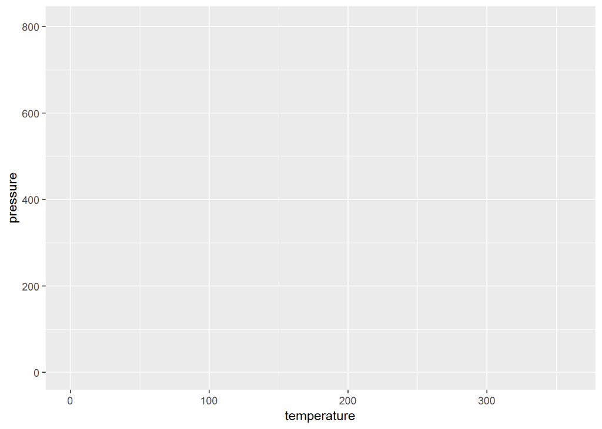

```r
library(ggplot2)
ggplot(data=pressure, aes(x=temperature, y=pressure))
```

R 내장 데이터인 pressure를 통해 좌표계를 그려주었습니다.

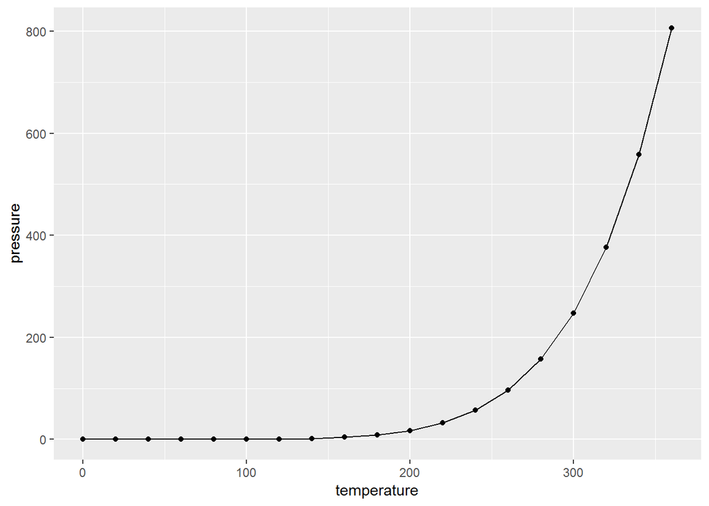

```r
library(ggplot2)

ggplot(data=pressure, aes(x=temperature, y=pressure))+
  geom_point()+
  geom_line()
```

+geom_point()+geom_line() 를 통해 어떤 타입의 그래프를 그릴지 설정 되었습니다. 좌표계에 포인트와  
라인 그래프가 추가된 것을 확인 할 수 있습니다.

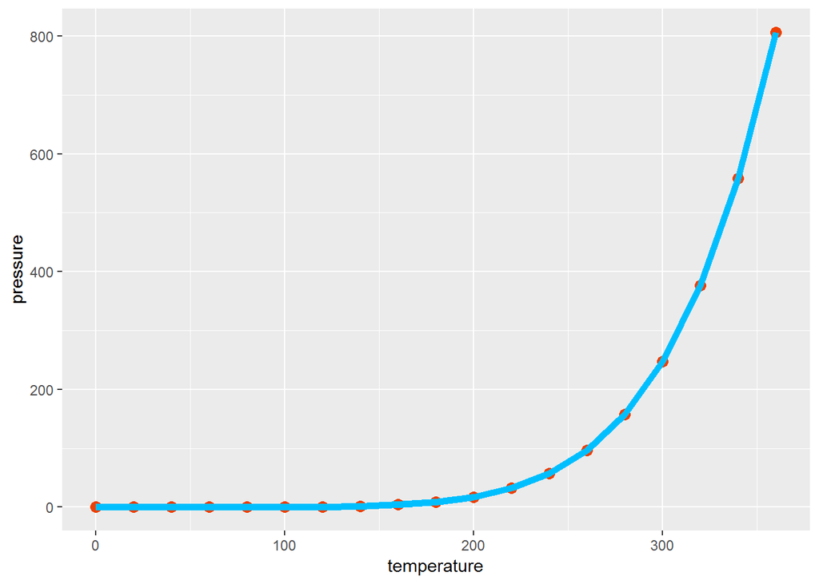

```r
library(ggplot2)

ggplot(data=pressure, aes(x=temperature, y=pressure))+
  geom_point(color='orangered2', size=3)+
  geom_line(color='deepskyblue', size=2)
```

이전 그래프에 색을 추가해 주었습니다. geom_point뒤의 ()안에서 자유롭게 색과 사이즈 설정이 가능합니다.  
그러나 이 그래프 에서는 point가 line에 가려져 잘 보이지 않습니다.

## **2. geom_bar 그래프 그리기**

bar 그래프는 아래와 같이 우리가 익숙히 알고 있는 막대그래프 입니다.  
이번 에는 ggplot2 패키지로 bar 그래프를 그리는 방법에 대해 알아보겠습니다.

ggplot에서 bar 그래프를 그리는 방식에는 크게 두 가지가 있습니다.

첫째, x축의 값만 지정하여 빈도를 나타내는 그래프  
둘째, x축과 y축의 값을 각각 지정하여 그리는 그래프

R의 base data인 sleep 과 ggplot2의 package data인 diamonds를 활용하여 각각의 그래프를 그려보도록 하겠습니다.

#### **2.1 x축 값만 지정한 그래프**

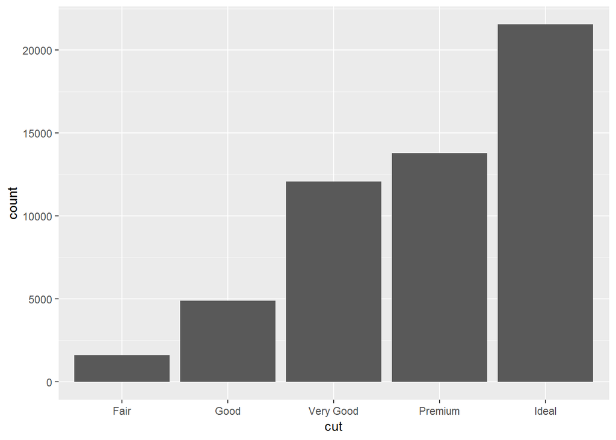

```r
library(ggplot2)
ggplot(diamonds, aes(cut))+
  geom_bar()
```

aes()안에는 x축 값만 입력하고, geom_bar()에 stat을 설정해주지 않습니다.  
사실 빈도수가 계산되도록 하기 위해선 geom_bar()에 stat=’count’를 입력해주어야 합니다.  
stat=’count’는 y축의 높이를 데이터의 빈도(count)로 표시하는 bar그래프 형식으로 나타내라는 뜻입니다.

하지만 이를 지정하지 않고도 자동으로 y축의 값이 빈도로 표시되는 이유는, stat=’count’가 bar그래프의 default 값이기 때문입니다.  
default 값이란 미리 정해져 있는 값이나 설정치를 의미하며, 특정한 값이나 설정치를 지정되지 않았을 때 이 defaut(디폴트)값을 사용합니다.  
즉, geom_bar함수에서는 stat=’count’가 default 값으로 설정되어 있어 따로 지정하지 않아도 자동적으로 stat=’count’의 형태가 적용된 것입니다.

#### **2.2 x축, y축 값을 지정한 그래프**

##### **2.2.1 기본 bar 그래프**

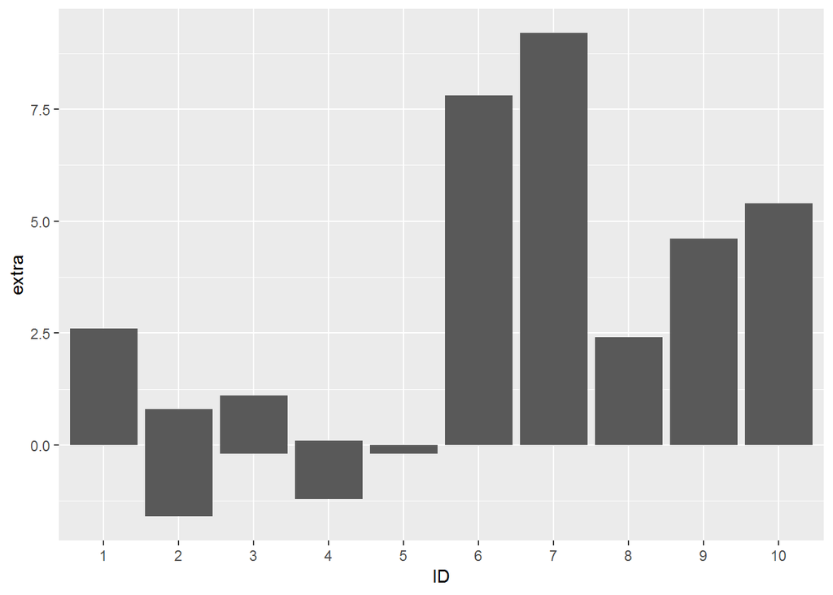

```r
library(ggplot2)
ggplot(sleep, aes(ID, extra))+
  geom_bar(stat='identity')
```

그래프를 그리기 위한 코드는 크게 두 부분으로 구성돼있습니다. 데이터를 바탕으로 그래프의 틀을 정해주는 ggplot과, 그래프의 형태를 정해주는 함수입니다. 그래프의 형태를 지정해주는 부분은 앞서 말한 레이어 추가 방식(+)을 통해 계속해서 지정해줄 수 있습니다.

가장 먼저 자료명을 입력하여 ggplot을 통해 그릴 그래프가 어떤 자료의 데이터를 기반으로 그릴 것인지를 정해줍니다.  
aes는 지정한 자료의 데이터를 바탕으로 그래프의 틀을 정해주는 함수입니다. 따라서 aes에서 데이터를 기반으로 하는 x축과 y축, 데이터 색상을 지정해줍니다.

그래프의 틀을 지정해주었으면 어떤 형식으로 그릴 것인지 정해주어야 합니다.  
bar그래프는 geom_bar()로 그릴 수 있습니다. 여기서 주의해야 할 점은 geom_bar() 안에 반드시 stat=’identity’를 입력해주어야 한다는 것입니다.  
stat은 ‘통계’의 뜻을 가진 ‘Statistic’의 약자로, bar 그래프의 형태에 대해 지정해줍니다.  
identity는 y축 값의 높이를 데이터를 기반으로 정해줄 때 사용해줍니다. 즉, stat=’identity’는 y축의 높이를 데이터의 값으로 하는 bar그래프의 형태로 지정한다는 것입니다.

##### **2.2.2 데이터의 종류를 한 그래프 안에 나눠서 표시해주는 bar 그래프**

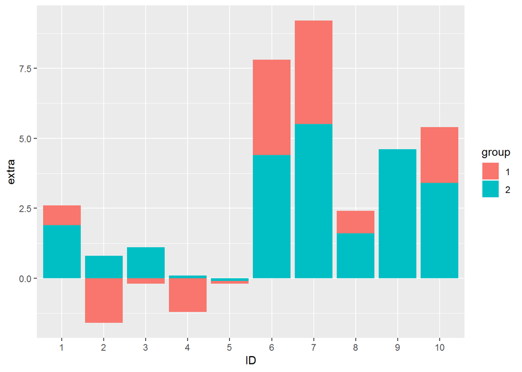

```r
library(ggplot2)
ggplot(sleep, aes(ID, extra, fill=group))+
  geom_bar(stat='identity')
```

이 그래프는 같은 ID내 존재하는 복수의 데이터, 즉 group을 색상으로 구분하여 표현하고, 범례에도 나타내고 있습니다.  
이전의 그래프와 차이가 있다면, aes(ID, extra)에 fill=group이 추가된 것입니다. aes는 자료의 데이터를 기반으로 한 그래프틀을 정해줄 때 사용하는 함수이고, group은 sleep 자료 내 데이터입니다.  
따라서 fill함수를 aes안에 써줌으로써 sleep내 데이터인 group에 색상이 지정된 것입니다.

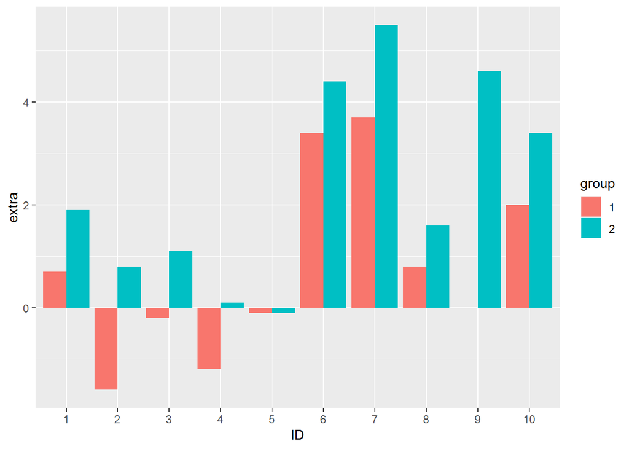

```r
library(ggplot2)
ggplot(sleep, aes(ID, extra, fill=group))+
    geom_bar(stat='identity', position = 'dodge')
```

이 그래프는 group데이터를 두 개의 독립적인 막대로 제시하고 있습니다.  
geom_bar()에 position = ‘dodge’ 함수를 더해주면 됩니다.

position은 막대의 위치를 의미합니다. dodge는 복수의 데이터를 독립적인 막대 그래프로 나란히 표현할 때 사용합니다.  
즉, position=’dodge’는 막대의 위치를 개별적인 막대로 나란히 표현하라는 명령어인 것입니다.  
단, 나란히 표시할 막대의 데이터를 fill 혹은 color 함수를 이용해 반드시 구분지어주어야 합니다.

##### **2.2.4 데이터의 종류룰 비율로 표시해주는 bar 그래프**

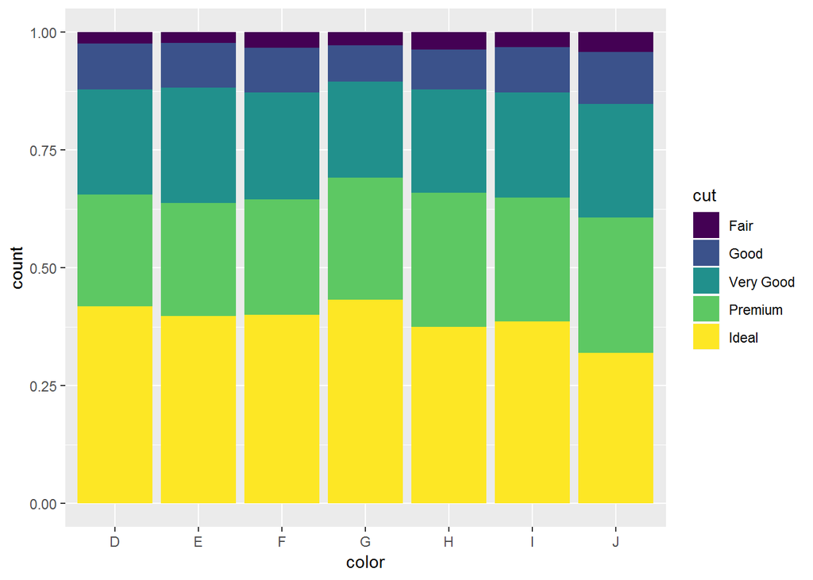

```r
library(ggplot2)
ggplot(diamonds, aes(color, fill=cut))+
    geom_bar(position='fill')
```

position=’fill’은 말 그대로 막대 그래프를 화면에 꽉 채워, x값 내의 데이터의 상대적인 비율을 나타내줄 때 씁니다.

##### **2.2.5 가로 그래프**

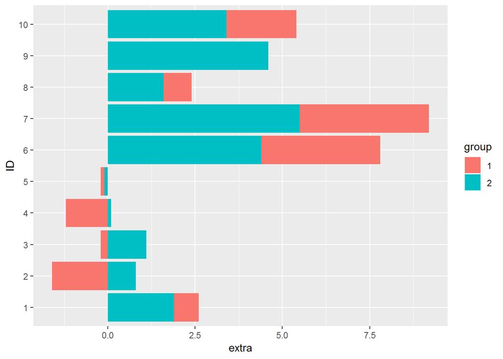

```r
library(ggplot2)
ggplot(sleep, aes(ID, extra, fill=group))+
    geom_bar(stat='identity')+
    coord_flip()
```

coord는 ’coordinate’의 약자로 조정하고 꾸미는 것을 의미하며, flip은 ’뒤집다’의 뜻을 가지고 있습니다. 즉, coord_flip()은 x축과 y축의 구성을 뒤집어 표현하라는 명령어이며, x축과 y축의 위치가 바뀜과 동시에 가로의 막대로 값을 표현하는 bar그래프가 그려지도록 해줍니다.

coord_flip은 데이터를 기반으로 하지 않고, bar그래프에 대한 함수도 아니기 때문에 ggplot과 geom_bar 함수 뒤에 레이어 추가 형식으로 지정해 줍니다.

##### **2.2.6 복수의 데이터를 나란히 표현해주는 가로그래프**

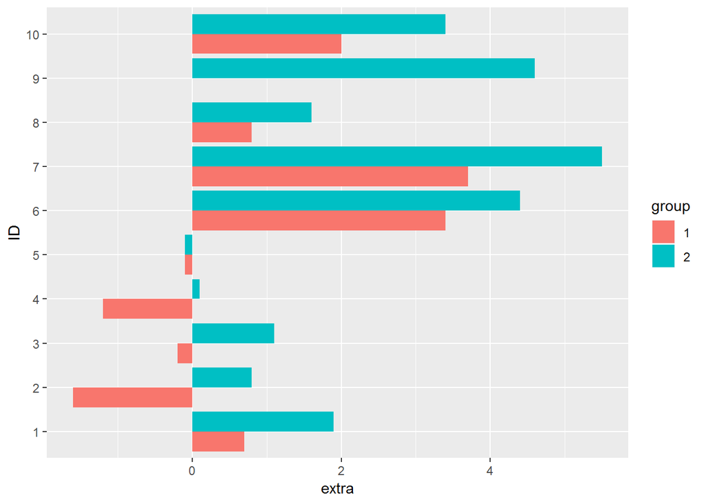

```r
library(ggplot2)
ggplot(sleep, aes(ID, extra, fill=group))+
    geom_bar(stat='identity', position = 'dodge')+
  coord_flip()
```

position=‘dodge’ 함수와 coord_flip함수를 동시에 적용한 그래프입니다. 이렇게 ggplot은 그래프의 형태를 레이어 추가 방식을 통해 복수의 명령을 간편하게 지정할 수 있습니다.  
단, position은 한 가지만 설정할 수 있습니다. position=‘dodge’, position=fill 은 불가능합니다.

##### **2.2.7 음수와 양수 막대 다르게 색상 입히기**

데이터 준비 : gcookbook 패키지의 데이터

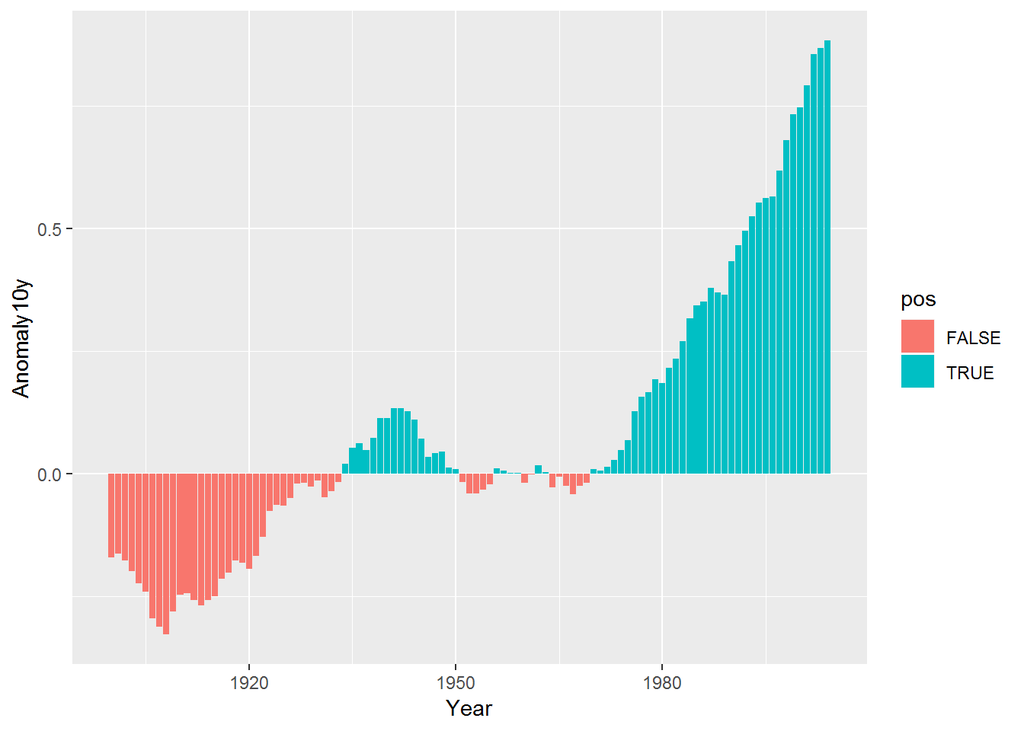

```r
library(gcookbook)
csub <- subset(climate, Source == "Berkeley" & Year >= 1900)
csub$pos <- csub$Anomaly10y >= 0
ggplot(csub, aes(x = Year, y = Anomaly10y, fill = pos)) +
  geom_col()
```

scale_fill_manual() 을 사용해 색깔을 바꾸고, guide=FALSE 로 범례를 지운 그래프 입니다.

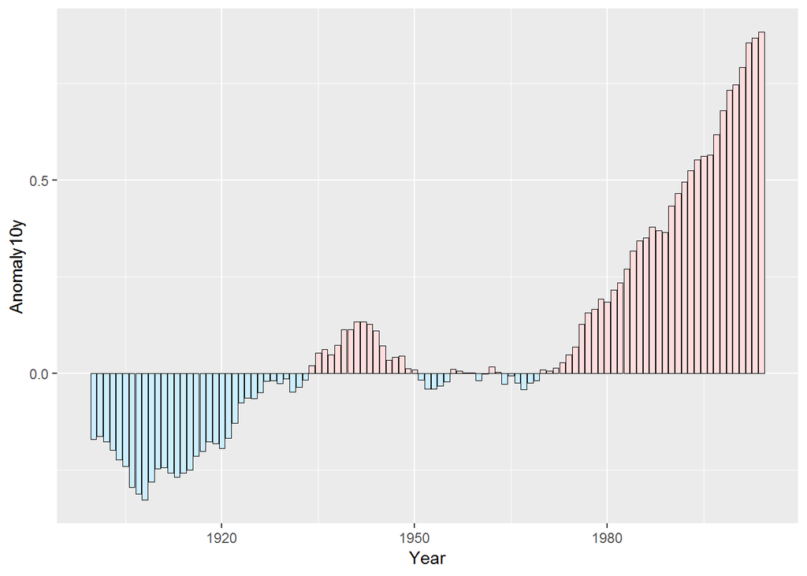

```r
ggplot(csub, aes(x = Year, y = Anomaly10y, fill = pos)) +
  geom_col(colour = "black", size = .25) +
  scale_fill_manual(values = c("#CCEEFF", "#FFDDDD"), guide = FALSE)
```

##### **2.2.8 막대 그래프를 이용한 파이-도넛 차트**

일반적으로 파이그래프는 자료를 표현하는데 있어 그리 좋은 방법은 아닌 것으로 알려져 있다.  
특히 자료의 갯수가 많아 질 경우 파이 그래프보다 도넛 그래프가 더 좋은 것으로 알려져 있다.  
이번 목표는 파이그래프와 donut plot을 결합하여 보기 좋은 그래프를 만드는 것이다.  
다음과 같은 자료가 있다고 하자.

```r
data <- data.frame(browser = c("MSIE","MSIE","MSIE","MSIE","Firefox","Firefox","Firefox","Chrome","Safari","Safari","Opera"),
                   version = c("MSIE 6.0","MSIE 7.0","MSIE 8.0","MSIE 9.0","Firefox 3.5","Firefox 3.6","Firefox 4.0","Chrome 10.0","Safari 4.0","Safari 5.0","Opera 11.x"),
                   share = c(10.35, 7.35, 33.06, 2.81, 1.58, 13.12, 5.43, 9.91, 1.42, 4.55, 1.65))
```

먼저 Pie plot과 Donut plot을 비교해보자. ggplot2의 geom_rect()및 coord_polar()를 이용하면 간단하게 파이차트와 도넛차트를 그릴 수 있다.  
geom_rect()를 이용하려면 ymin, ymax, xmin, xmax 좌표를 지정해주어야 한다. *단, geom_bar 함수로는 불가능하다..*

차트를 그리기 위하여 먼저 다음과 같이 자료를 전처리한다.

```r
library(dplyr)
data1 <- data %>%
  mutate(ymax = cumsum(share),
         ymin = cumsum(share)-share,
         ypos = ymin + (share/2),
         ratio = share / sum(share) * 100)
```

먼저 geom_rect()를 이용하여 막대그래프를 만들어보자.

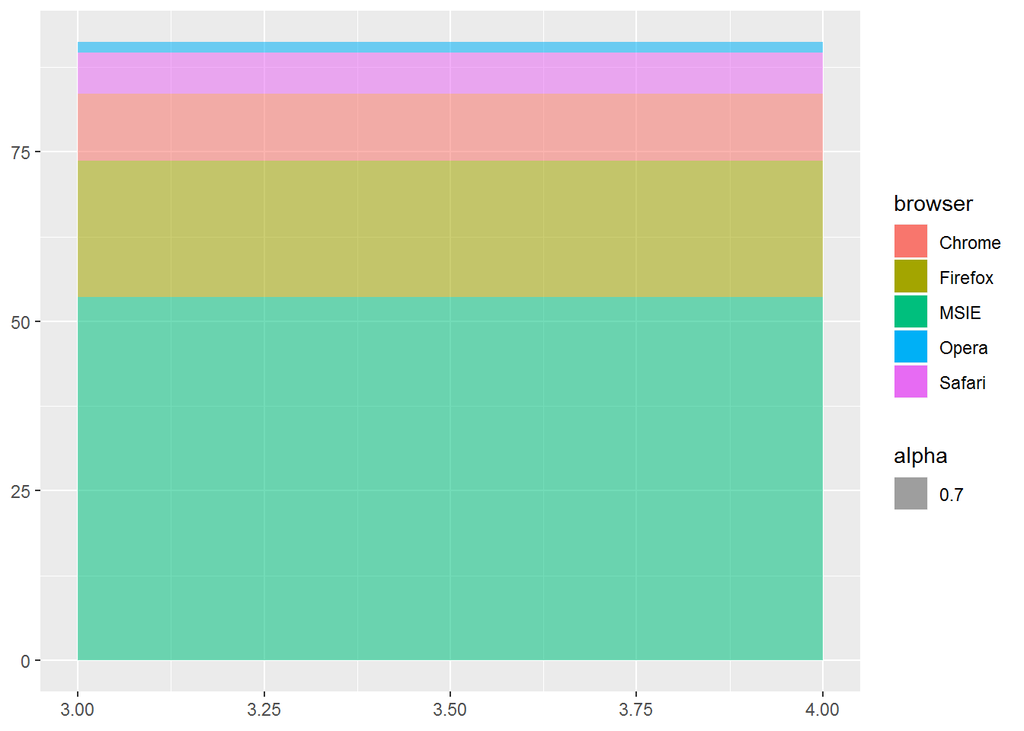

```r
p <- ggplot(data1)+
  geom_rect(aes(xmin=3,xmax=4,ymin=ymin,ymax=ymax, fill=browser, alpha=0.7))
p
```

이제 coord_polar()를 이용하여 좌표계를 원형좌표계로 변환한다. 양궁에서 쓰이는 과녁과 비슷한 Buul’s eye plot이 그려진다.

```r
p1 <- p +
  coord_polar()
```

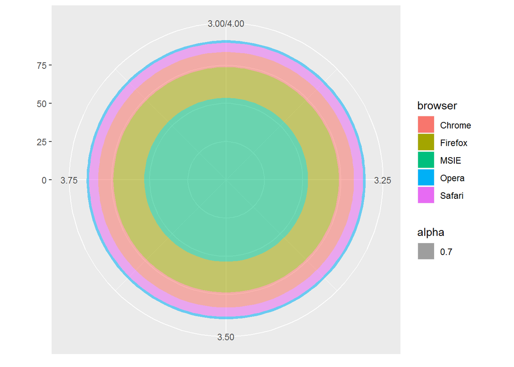

```r
p1
```

이를 Pie plot으로 변환하려면 coord_polar의 theta옵션을 “y”로 주면 된다.

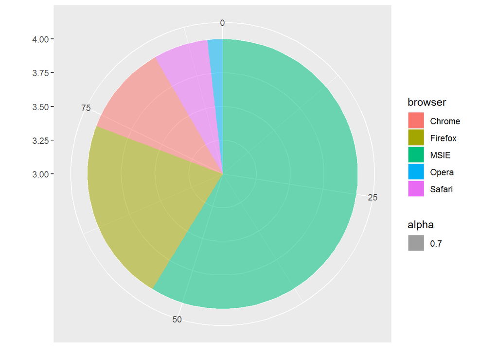

```r
p1 <- p +
  coord_polar(theta = "y")
p1
```

이 그래프를 Donut plot으로 바꾸는 것은 x축의 좌표의 범위만 바꾸어 주면 된다.

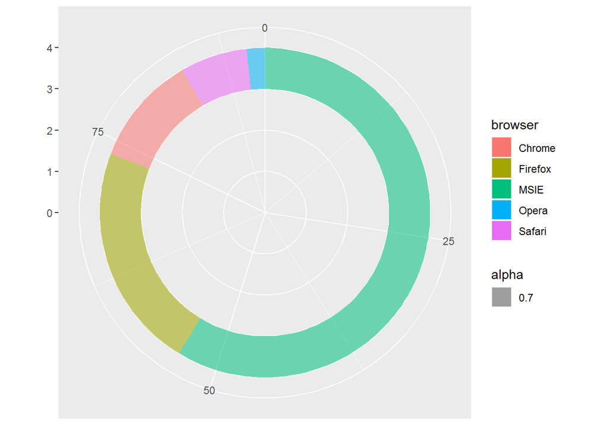

```r
p1 <- p +
  coord_polar(theta = "y") +
  xlim(0,4)
p1
```

범례와 불필요한 축을 없애고, 대신 browser version을 각 모형에 표시하면 다음과 같다.

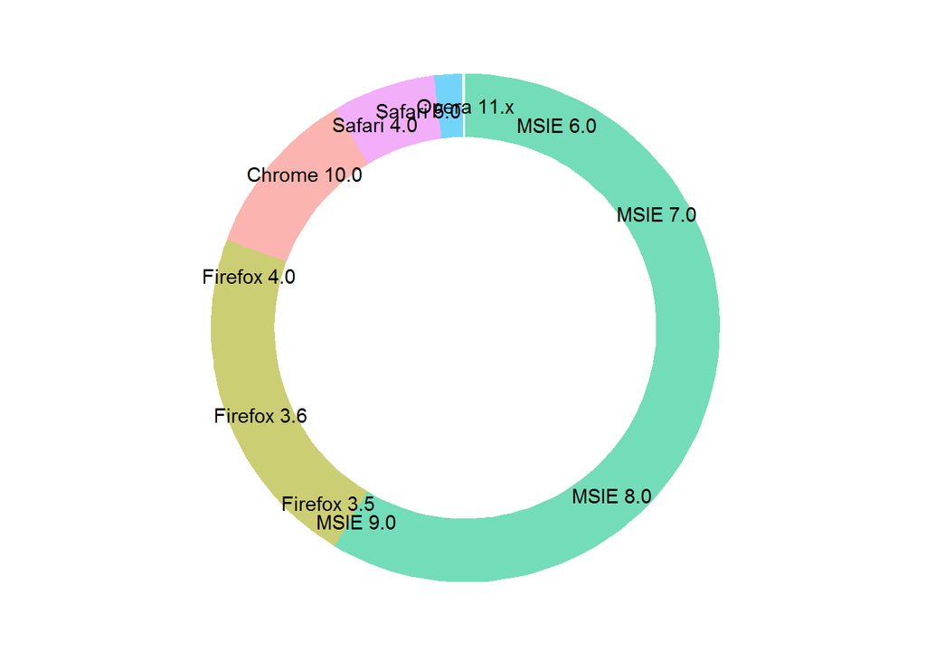

```r
p2 <- p1 +
  geom_text(aes(x=3.5,y=ypos+1,label=version))+
  guides(fill=FALSE) +
  theme(axis.title = element_blank(),       # 축 타이틀 삭제
        axis.text = element_blank(),        # 축 텍스트 삭제
        axis.ticks = element_blank(),       # 축 ticks  삭제
        panel.background = element_blank(), # 패널 배경 삭제
        legend.position = "neon"            # 범례삭제
        )

p2
```

다음으로 Donut plot에 Pie plot을 다음과 같이 결합할 수 있다. 먼저 pie plot을 그리기 위한 데이타 전처리가 필요하다.

```r
data2 <- data1 %>%
  group_by(browser) %>%
  summarise_each(list(sum), sum = share) %>%
  arrange(desc(sum)) %>%
  mutate(cumsum = cumsum(sum),
         pos = cumsum - (sum/2),
         ymin = cumsum - sum,
         ratio = sum/sum(sum)*100)
```

이제 이렇게 만들어진 data2를 이용하여 기존의 plot에 파이그래프를 덧그린다.

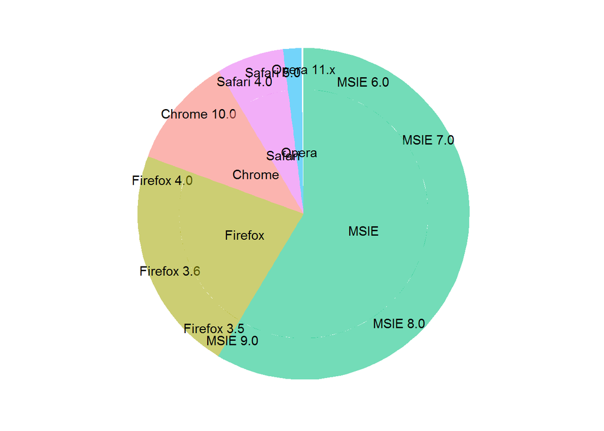

```r
p3 <- p2 +
  geom_rect(data=data2, aes(xmin=0, xmax=3, ymin=ymin, ymax=cumsum,fill=browser, alpha=0.7)) +
  geom_text(data=data2, aes(x=1.5, y=pos, label=browser))
p3
```